# Week 6 Workshop K

Author

Liam N

## Introduction

As this is our last workshop, and as many of us are learning about some of the techniques in this module for the first time, I thought we could spend some time looking at some novel applications of data science and AI (ssh don’t tell the other Lecturer) using `R`. Some of the topics today have been adopted from the [Learning Machines Blog](https://blog.ephorie.de/) of Professor. Holger K. von Jouanne-Diedrich from the Technical University, Aschaffenburg in Bavaria, Germany. Holger is a good friend to the department and we have hosted his students here in the past as well as sending some of ours over there to see him. He is the author of the `OneR` a machine learning classification package which implements the one rule classification approach. He is also an excellent tour guide, especially of the pubs of Aschaffenburg. I recommend his blog to any aspiring data scientist or machine learning engineer.

## `k-`nearest neighbours and handwriting analysis.

You may have come across this algorithm elsewhere and it works like this. “What is the best way for me to find out whether you are rich or poor, when the only thing I know is your address? Looking at your *neighbourhood*! That is the big idea behind the *k-nearest neighbours (or KNN)* algorithm, where *k* stands for the *number of neighbours* to look at.”

Let us take a task that is very hard to program from scratch, such identifying handwritten numbers. We will be using the [Semeion Handwritten Digit Data Set from the UCI Machine Learning Repository](http://archive.ics.uci.edu/ml/datasets/Semeion+Handwritten+Digit). First we should download the data from here. Next, beacuse this is the last week and we can do what we want we will cheat a little by using a `plot_digit` function from the blog. This function is used for plotting images of digits in a nice way and returning the respective number.

```r
plot_digit <- function(digit) {
  M <- matrix(as.numeric(digit[1:256]), nrow = 16, ncol = 16, byrow = TRUE)
  image(t(M[nrow(M):1, ]), col = c(0,1), xaxt = "n", yaxt = "n", useRaster = TRUE)
  digit[257]
}
```

Now we read the data. It’s a table so for this data set we’ll do:

```r
semeion <- read.table("semeion.data", quote = "\"", comment.char = "")
```

Remind me to show you how to set the working directory! Next we’ll choose some digits as examples.

```r
digit_data <- semeion[ , 1:256]
which_digit <- apply(semeion[ , 257:266], 1, function(x) which.max(x) - 1)
semeion_new <- cbind(digit_data, which_digit)
```

Next we’ll split the data into a training and test set at random.

```r
set.seed(123)
data <- semeion_new
random <- sample(1:nrow(data), 0.8 * nrow(data)) # 80%: training data, 20%: test data
train <- data[random, ]
test <- data[-random, ]
```

And now we’ll use the *plot_digit* function to plot some digits.

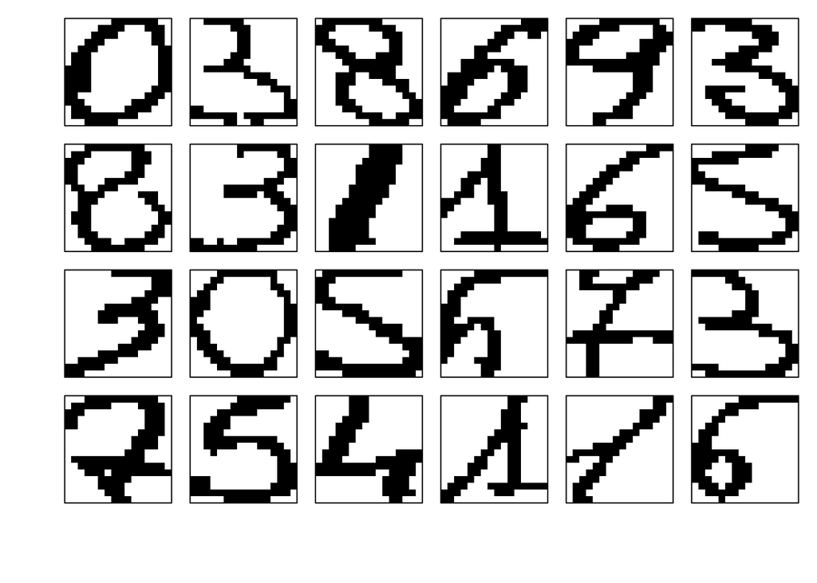

```
     [,1] [,2] [,3] [,4] [,5] [,6]
[1,]    0    3    8    6    9    3
[2,]    8    3    1    1    6    5
[3,]    3    0    5    5    7    3
[4,]    7    5    4    1    1    6
```

```r
old_par <- par(mfrow = c(4, 6), oma = c(5, 4, 0, 0) + 0.1, mar = c(0, 0, 1, 1) + 0.1)
matrix(apply(train[1:24, ], 1, plot_digit), 4, 6, byrow = TRUE)
```

```r
par(old_par)
```

As you can see teaching a computer to read those digits is a task that would take considerable effort and easily hundreds of lines of code. You would have to intelligently identify different regions in the images and find some boundaries to try to identify which number is being shown. You could expect to do a lot of tweaking before you would get acceptable results.

The real magic behind machine learning and AI is that when something is too complicated to program from scratch we can let the machine program itself by just showing it lots of examples. We will do just that with the nearest neighbour algorithm.

When talking about neighbours we need some kind of distance metric to define what constitutes a neighbour. As in real life, the simplest one is the so-called Euclidean distance which is just how far different points are apart from each other as the crow flies. The simple formula that is used for this is just the good old Pythagorean theorem.

```r
dist_eucl <- function(x1, x2) {
  sqrt(sum((x1 - x2) ^ 2)) # Pythagorean theorem!
}
```

The k-nearest neighbours algorithm is pretty straight forward: it just compares the digit which is to be identified with all other digits and choses the k nearest ones. In case that the k nearest ones don’t come up with the same answer the majority vote (or mathematically the mode) is taken:

```r
mode <- function(NNs) {
  names(sort(-table(NNs[ncol(NNs)])))[1] # mode = majority vote
}
knn <- function(train, test, k = 5) {
  dist_sort <- order(apply(train[-ncol(train)], 1, function(x) dist_eucl(as.numeric(x), x2 = as.numeric(test[-ncol(test)]))))
  mode(train[dist_sort[1:k], ])
}
```

The algorithm itself comprises barely 4 lines of code! Now, let us see how it performs on this complicated task with k = 9 out of sample (first a few examples are shown and after that we have a look at the overall performance):

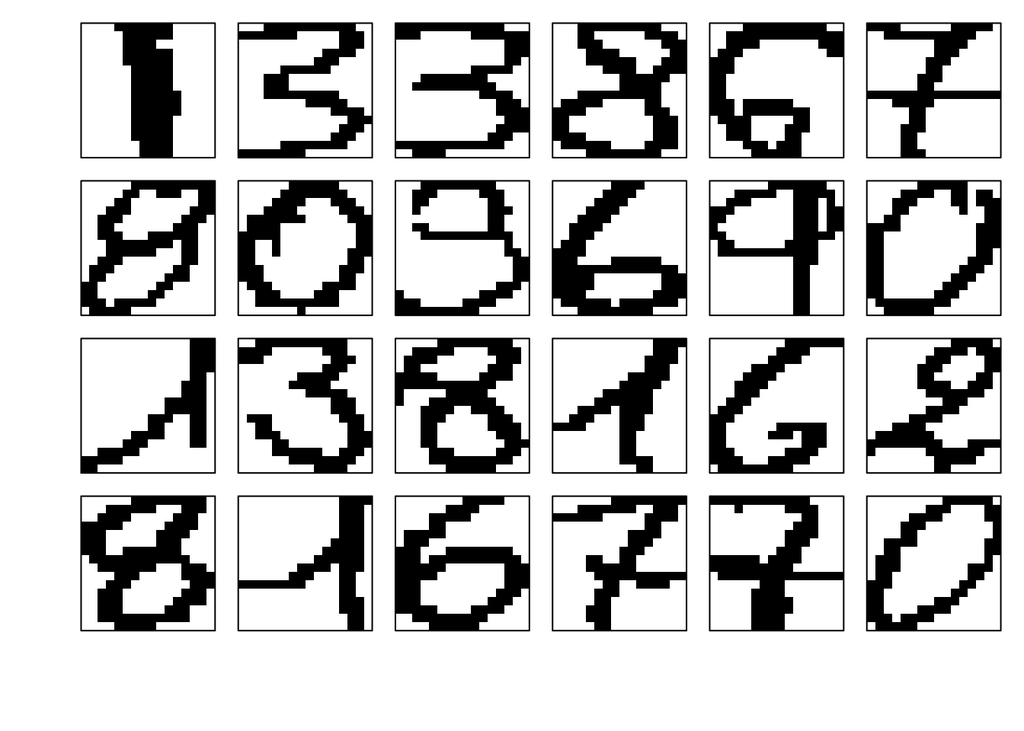

```
     [,1] [,2] [,3] [,4] [,5] [,6]
[1,]    1    3    3    8    6    7
[2,]    8    0    9    6    9    0
[3,]    1    3    8    1    6    2
[4,]    8    1    6    7    7    0
```

```r
set.seed(123) # for reproducibility
no_examples <- 24
examples <- sample(dim(test)[1], no_examples)
old_par <- par(mfrow = c(4, 6), oma = c(5, 4, 0, 0) + 0.1, mar = c(0, 0, 1, 1) + 0.1)
matrix(apply(test[examples, ], 1, plot_digit), 4, 6, byrow = TRUE)
```

```r
par(old_par)
prediction <- integer(no_examples)
for (i in 1:no_examples) {
  prediction[i] <- knn(train, test[examples[i], ], k = 9)
}
print(matrix(prediction, 4, 6, byrow = TRUE), quote = FALSE, right = TRUE)
```

```
     [,1] [,2] [,3] [,4] [,5] [,6]
[1,]    1    3    3    8    6    7
[2,]    8    0    3    6    9    0
[3,]    1    3    8    1    6    2
[4,]    3    1    6    7    7    0
```

Now we check the accuracy.

```r
library(OneR) # just for eval_model function to evaluate the model's accuracy
prediction <- integer(nrow(test))
ptm <- proc.time()
for (i in 1:nrow(test)) {
  prediction[i] <- knn(train, test[i, ], k = 9)
}
proc.time() - ptm
```

```
   user  system elapsed
 11.150   0.001  11.150
```

```r
eval_model(prediction, test[ncol(test)], zero.print = ".")
```

```
Confusion matrix (absolute):
          Actual
Prediction   0   1   2   3   4   5   6   7   8   9 Sum
       0    37   .   .   .   .   .   .   .   1   1  39
       1     .  30   .   1   2   .   .   5   .   3  41
       2     .   .  29   1   .   .   .   .   2   1  33
       3     .   .   .  23   .   .   .   .   2   2  27
       4     .   .   .   .  28   .   .   .   .   .  28
       5     .   .   .   .   .  36   .   .   .   2  38
       6     1   .   .   .   .   .  39   1   .   .  41
       7     .   .   .   1   .   .   .  26   .   .  27
       8     .   .   .   .   .   .   .   .  23   .  23
       9     .   .   .   .   .   .   .   .   .  22  22
       Sum  38  30  29  26  30  36  39  32  28  31 319

Confusion matrix (relative):
          Actual
Prediction    0    1    2    3    4    5    6    7    8    9  Sum
       0   0.12    .    .    .    .    .    .    .    .    . 0.12
       1      . 0.09    .    . 0.01    .    . 0.02    . 0.01 0.13
       2      .    . 0.09    .    .    .    .    . 0.01    . 0.10
       3      .    .    . 0.07    .    .    .    . 0.01 0.01 0.08
       4      .    .    .    . 0.09    .    .    .    .    . 0.09
       5      .    .    .    .    . 0.11    .    .    . 0.01 0.12
       6      .    .    .    .    .    . 0.12    .    .    . 0.13
       7      .    .    .    .    .    .    . 0.08    .    . 0.08
       8      .    .    .    .    .    .    .    . 0.07    . 0.07
       9      .    .    .    .    .    .    .    .    . 0.07 0.07
       Sum 0.12 0.09 0.09 0.08 0.09 0.11 0.12 0.10 0.09 0.10 1.00

Accuracy:
0.9185 (293/319)

Error rate:
0.0815 (26/319)

Error rate reduction (vs. base rate):
0.9071 (p-value < 2.2e-16)
```

We achieve a high accuracy out of the box while some of the digits are really hard to read even for humans! And we haven’t even given it the information that those images are two-dimensional because we coded all the images simply as (one-dimensional) binary numbers. To get the idea where it failed have a look at the digits that were misclassified:

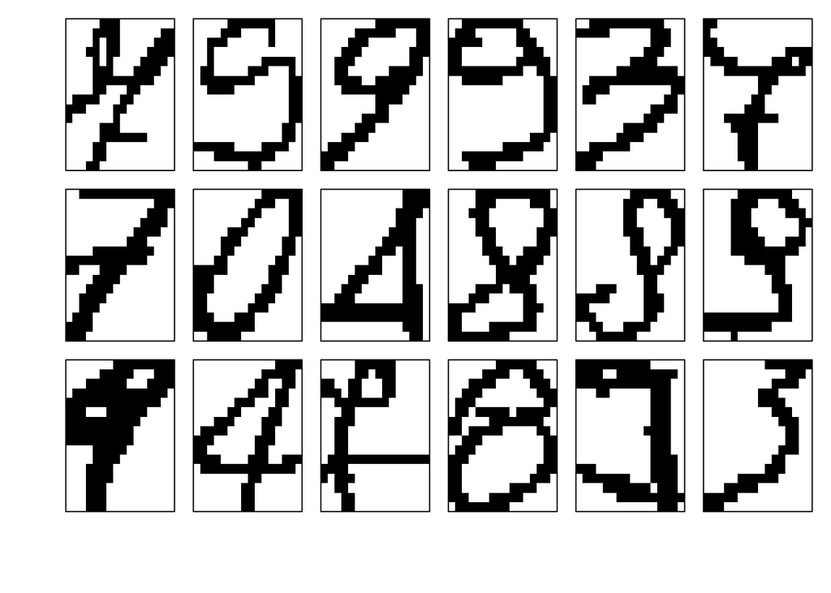

```
     [,1] [,2] [,3] [,4] [,5] [,6]
[1,]    7    9    9    9    3    7
[2,]    7    0    4    8    8    9
[3,]    9    4    7    8    9    3
```

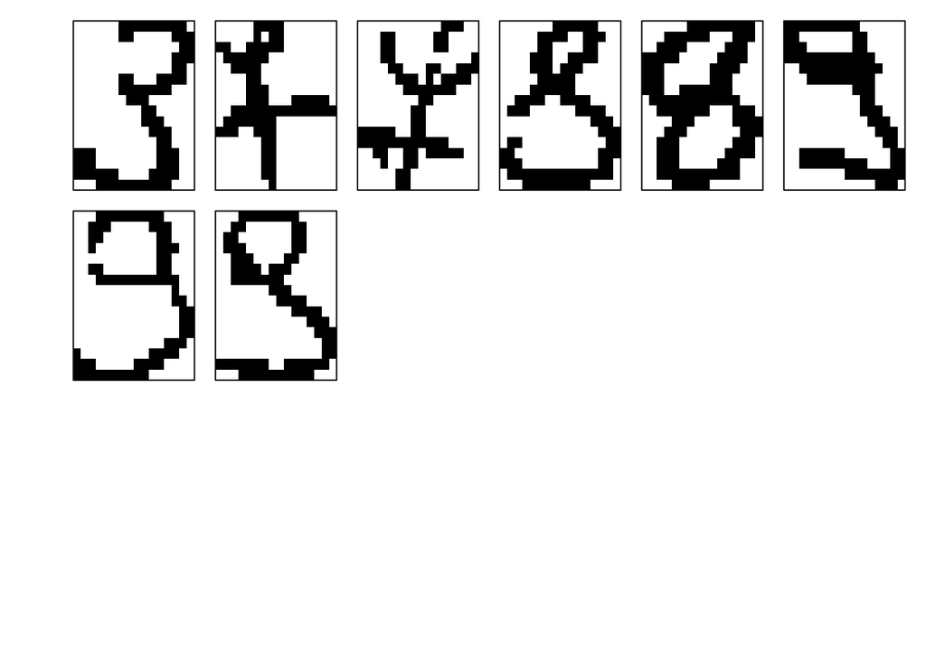

```r
err <- which(as.integer(prediction) != unlist(test[ncol(test)]))
old_par <- par(mfrow = c(3, 6), oma = c(5, 4, 0, 0) + 0.1, mar = c(0, 0, 1, 1) + 0.1)
matrix(apply(test[err, ], 1, plot_digit), 3, 6, byrow = TRUE)
```

Most of us would have trouble reading those digits too!

## Cluster Analysis and the Bible

As most people know the New Testament comprises four different Gospels attributed to Matthew, Mark, Luke and John which were written around about 50-70AD. Unfortunately, we have lost all of the originals but only retained copies of copies of copies (and so on) which date back hundreds of years after they were written in all kinds of different versions.

One interesting question is how do the four Gospels relate to each other. To find that out you could either study Greek (i.e. the language of the New Testament) and Christian theology for many years and decades – or you could use Natural Language Processing (NLP) in the form of the `stylo` package and do a cluster analysis within seconds.

```r
library(stylo)
```

Now we run

```
using current directory...
```

```
Performing no sampling (using entire text as sample)
```

```
slicing input text into tokens...
```

```
turning words into features, e.g. char n-grams (if applicable)...
```

```
Total nr. of samples in the corpus: 4
```

```
The corpus consists of 70943 tokens
```

```
processing  4  text samples
```

```
combining frequencies into a table...
```

```
culling @ 0 available features (words) 5000
```

```
Calculating z-scores...
```

```
Calculating classic Delta distances...
```

```
MFW used:
```

```
200
Processing metadata...


Assigning plot colors according to file names...
```

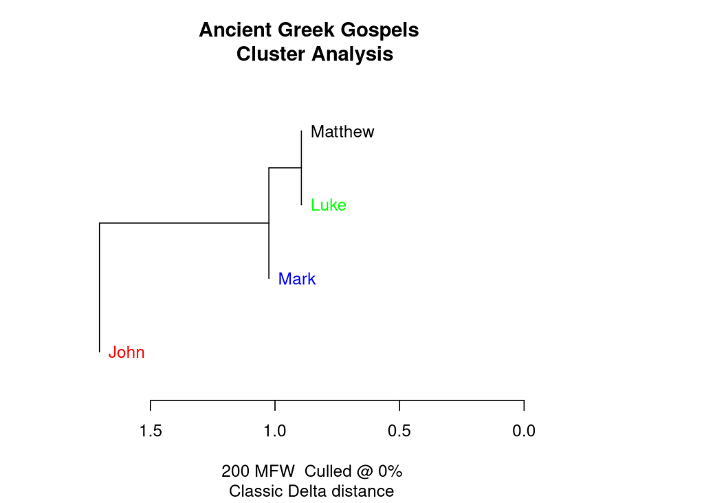

[output not shown]

```r
stylo(corpus.lang = "Other", encoding = "UTF-8", mfw.min = 200, mfw.max = 200, custom.graph.title = "Ancient Greek Gospels", gui = FALSE)
```

As you can see, Biblical scholars have found out that Luke and Matthew share about 60 to 70 percent of the text (through the so-called double tradition), whereas Mark shares about 40 percent of the text (through the triple tradition). For comparison, John only shares about 10 percent with the synoptic Gospels. Now, this is exactly what our cluster analysis form above shows – what an impressive feat!

It has never been easier to do sophisticated textual analyses, even in ancient languages one cannot understand! You might ask: how did R do that?

Well, behind the scenes R basically creates frequency tables for the words used in the different documents. It then tries to cluster the documents based on a similarity (or distance) measure. Intuitively that means that the more often authors use the same words the closer their texts are. As you can see R doesn’t really have to understand the words or the language used. It just maps statistical measures which seems to be quite effective (not only) in this case. The statistical measures often give some kind of characteristic signature of an author or a source. In a way, this is the quantified version of fuzzy concepts like ‘writing style’ yet R can do it much more quickly even for long texts than any human ever could!

## Understanding ChatGPT

Now it’s your turn. For the rest of this session, and for the rest of your lives, I want you to visit this blog regularly to learn. Start with [Understanding ChatGPT](https://blog.ephorie.de/attention-what-lies-at-the-core-of-chatgpt#more-6295).